# Food Preparation

Lichtenberk, F. and Osmond, M.

## 1. Introduction

Much of this chapter is reproduced from Lichtenberk (1994), reordered and slightly revised in the light of more stringent subgrouping assumptions.[^1] To that work have been added a number of terms related to fire and its accompaniments. Organization of the chapter is (1) fire and the fireplace; (2) cooking methods; (3) preservation and (4) food processing.

## 2. Fire and the fireplace

There is a well-attested term for fire that can be traced back to PAn:

| **PAn** |  | *Sapuy | ‘fire’ (ACD) |
| --- | --- | --- | --- |
| **POc** |  | *api | ‘fire’ |
| Adm | Wuvulu | *afi* |  |
| NNG | Gitua | *yap* |  |
| NNG | Numbami | *yawi* |  |
| PT | Motu | *lahi* |  |
| PT | Bwaidoga | *ai* |  |
| MM | Nakanai | *havi* |  |
| NCV | Mota | *av* |  |
| Mic | Kiribatese | *al* |  |
| Mic | Woleaian | *yaf* |  |
| Pn | Tongan | *afi* |  |
| Pn | Hawaiian | *ahi* |  |

### 2.1. Fire plough

Fire was produced throughout the Oceanic world by friction. Often this was achieved by rubbing a piece of wood rapidly to and fro along a long groove or furrow cut into a second piece of wood. We have a term specifically for the action of lighting a fire with fire-plough. Note that the Central Pacific terms have unexplained vowel fronting.

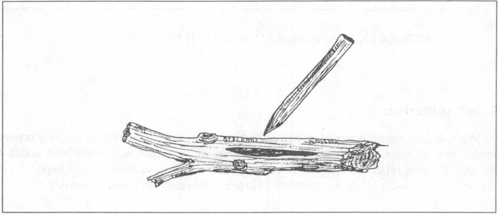

**Figure 19:** POc *suka, *suka-i ‘make fire with fire-plough’

| **POc** |  | *suka, *suka-i- | ‘make fire with fire-plough’ |
| --- | --- | --- | --- |
| Adm | Lou | *sok* | ‘rub a friction stick against wood to make fire’ |
| MM | Nakanai | *suka* | ‘the making of fire with the fire-plough; a fire-plough’ |
| MM | Tolai | *uk* | ‘bore through, bore into’ |
| SES | Lau | *su-sukai* | ‘bore’ |
| SES | Lau | *su-suka* | ‘a gimlet’ |
| Fij | Rotuman | *siʔa* | ‘make fire by friction’ |
| Pn | Rennellese | *sika* | ‘make fire by the fire-plough’ |
| Pn | Samoan | *siʔa* | ‘light a fire by friction; apparatus (fire-plough) as a whole; base wood of fire-plough’ |
| Pn | Tikopia | *sika* | ‘rub in groove, frictionate’ |

A second term is POc *usu(q,p), from PMP *usuq whose primary meaning is probably ‘rub abrasively’, but which in a number of Oceanic languages is recorded as meaning ‘rub to make fire’.

| **PMP** |  | *usuq | ‘rub, wipe’ (ACD) |
| --- | --- | --- | --- |
| **POc** |  | *usu(q,p), *usu(p)-i | ‘rub abrasively’ |
| PT | Motu | *udu-* | ‘rub a stick to make fire’ |
| MM | Nakanai | *huru* | ‘remove outside of shell by rubbing’ |
| MM | Tolai | *ū* | [VT,VI] ‘wipe’ |
| SES | Gela | *uhu* | ‘rub, rub fire, scrape off skin by rubbing, cut design on forehead’ |
| SES | Sa’a | *usu* | ‘rub, scrape, grate’ (*usu ʔei* ‘a firestick’) |
| SES | Lau | *usu, usufi-* | ‘rub, wipe, rub off’ |
| Mic | Mokilese | *it* | ‘start a fire using sticks’ |

Biggs (1993) has reconstructed PPn *kau-natu, for the implement used. Although this compound is derived from POc elements (POc *kaiu ‘tree, wood, stick’ and POc *natu ‘child’), we have no proof that the compound itself is POc. We can be confident, however, that the term is older than PPn, given that POc *kaiu was replaced by PPn *raqakau ‘wood, tree’, and POc *natu by PPn *tama ‘child’.

A separate term for the upper frictioning stick can be reconstructed, but only for the Central Eastern subgroup of Polynesia:

| **PCEPn** |  | *kau-lima | ‘upper frictioning stick of fire-plough’ (‘stick’ + ‘hand’) |
| --- | --- | --- | --- |
| Pn | Hawaiian | *ʔau-lima* | ‘stick held in the hand when making fire’ |
| Pn | Māori | *kau-rima-rima* | ‘upper stick of fire-plough’ |
| Pn | Tuamotuan | *kau-rima* | ‘the upper frictioning stick in the fire-plough’ |

A Papuan Tip language, Minaveha, likewise uses a compound term for the upper frictioning stick which includes the term for ‘hand’, *nima-kabi* (*nima* ‘hand’ + *kabi* ‘?’). In at least two places, Sissano (NNG) and Nakanai (MM), the upper fire stick is referred to by the term for penis (*etin* in Sissano, *huti* in Nakanai), both reflexes of POc *quti(n).

Across the Oceanic region it is possible to find some variation in fire-making methods, although we have no reconstructions for methods other than by fire-plough. Bing on the PNG north coast and Mapos Buang in the Huon Gulf area (both NNG) offer evidence for a method in which rattan or vine is sawn rapidly around a piece of wood:

| NNG | Mapos Buang | *vaŋkɛ rurŋ* | ‘make a fire by the traditional method using a piece of rattan, sawing it back and forth around a piece of dry wood with a split in it, lying on a little pile of tinder’ |
| --- | --- | --- | --- |
| NNG | Bing | *baŋ-baŋ* | ‘fire-stick and vine’ |

Another north coast language, Gedaged, has a term, *wol*, referring to a bow string. Fire is produced by pulling a bow string rapidly back and forth over a piece of wood. The action implied may be the same as in Carolinian *bʷuru-bʷur* ‘make a fire by generating friction with a traditional drill’ (from POc *buru ‘bore a hole, drill’ ; see Ch. 9, §4.2).

### 2.2. Firewood

In addition to the general term POc *kaiu ‘wood, stick’, we can reconstruct a PEOc term *papia, specifically for firewood. Note that an identical term is reconstructable for PEOc (cognates in SES and Fiji) with the meaning ‘cook in native oven’ (§3.1).

| **PEOc** |  | *papia | ‘firewood, fuel’ |
| --- | --- | --- | --- |
| Mic | Kiribatese | *aia* |  |
| Mic | Woleaian | *fafiya* |  |
| Pn | Tongan | *fefie* |  |
| Pn | Samoan | *fafie* |  |
| Pn | Māori | *wahie* |  |

### 2.3. Firebrand, torch

Blust has reconstructed a PMP term for wood alight but not yet consumed:

| **PMP** |  | *aluten | ‘firebrand, unconsumed wood in a fire; charred wood’ (ACD) |
| --- | --- | --- | --- |
| **POc** |  | *alito(n) | ‘firebrand’ |
| NNG | Takia | *yalit* | ‘piece of wood with fire burning in it’ |
| NCV | Mota | *lito* | ‘firewood’ |
| Fij | Wayan | *lito* | ‘shake a burning stick to make it glow brightly’ |
| Fij | Bauan | *lito* | ‘wave a firebrand; keep it alight’ |

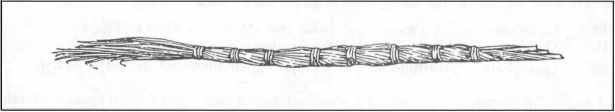

**Figure 20:** POc *sulu ‘dry coconut leaf torch’

A burning brand, typically made from coconut fronds, served as a torch.

| **POc** |  | *sulu | ‘dry coconut leaf torch’ (Milke 1961) |
| --- | --- | --- | --- |
| Adm | Lou | *sul* | ‘coconut frond (used for torches)’ |
| Adm | Titan | *sūlu* | ‘torch used for scorching canoe hulls and outriggers, made of coconut fronds’ |
| NNG | Bing | *sul* | ‘lamp (traditional, made from old mats of woven coconut leaves)’ |
| NNG | Gedaged | *sul* |  |
| NNG | Takia | *sul* |  |
| MM | Lihir | *sul* | ‘torch’ |
| MM | Tolai | *ul* | ‘torch made of dry leaves of the coconut palm’ |
| SES | Longgu | *sulu* | ‘leaf, especially of coconut’ |
| NCV | Uripiv | *na-sul* | ‘coconut frond (esp. a dry one); a light (traditional use for dry coconut fronds)’ |
| SV | Sye | *ilwo* | ‘torch’ |
| Mic | Carolinian | *ul* | ‘torch made from the long hard outer husk of young coconuts’ |
| Mic | Mokilese | *tɨ̈l* |  |
| Fij | Rotuman | *sulu* | ‘torch’ |
| Pn | Niuean | *hulu* | ‘look for with light; torch’ |
| Pn | Māori | *huru* | ‘glow’ |

### 2.4. Fireplace, hearth

Green and Pawley (Ch. 3, §3.6) note a general term for fireplace or hearth, PMP *dapuR, POc *rapu(R), with a frequent secondary meaning, particularly in Oceania, of ‘ashes’. Compounding may be used to distinguish the fireplace as ‘place of ashes’.

| **PMP** |  | *dapuR | ‘hearth, fireplace’ (Dempwolff 1938) |
| --- | --- | --- | --- |
| **POc** |  | *rapu(R) | ‘hearth, fireplace; ashes’ |
| Adm | Nyindrou | *drahu (jih)* | ‘fireplace’ (*jih* ‘fire’) |
| PT | Motu | *rahu-rahu* | ‘ashes, fireplace’ |
| MM | Maringe | *(nak)rofu* | ‘ashes’ |
| SES | Gela | *ravu* | ‘ashes’ |
| SES | Arosi | *rahu* | ‘ashes’ |
| NCV | Mota | *(ta)rowo* | ‘white ashes of burnt-out wood’ |
| Fij | Wayan | *ravu* | ‘ashes’ (*mata-ravu* ‘fireplace’) |
| Fij | Bauan | *dravu* | ‘ashes’ (*matā-dravu* ‘fireplace’) |
| Pn | Samoan | *(magā)lafu* | ‘hearth’ |
| Pn | Tokelauan | *(gā)lafu* | ‘fireplace’ |
| Pn | Hawaiian | *lehu* | ‘ashes’ |

cf. also:

| Pn | Tongan | *(ta)lafu* | ‘fireplace on a boat’ |
| --- | --- | --- | --- |

There is a second term, PAn *qabu, POc *qapu, with similar reference. Blust (ACD) comments: “*qabu is among the most widespread and stable morphemes in the Austronesian family. It referred to ashes, and prototypically to the ashes in the fireplace (hence its recurrent replacement of PMP *dapuR in the meaning ‘hearth’).”

| **PAn** |  | *qabu | ‘ash, cinder, powder’ (ACD) |
| --- | --- | --- | --- |
| **POc** |  | *qapu | ‘ashes, dust’ |
| Adm | Mussau | *au* | ‘ash’ |
| Adm | Lou | *kɔp* | ‘dust’ |
| NNG | Gitua | *avu-avu* | ‘ash’ |
| PT | Iduna | *avu* | ‘ashes’ |
| PT | Motu | *kahu* | ‘ashes’ |
| MM | Nakanai | *havu* | ‘lime (made from burnt shells)’ |
| SES | To’aba’ita | *afufu* | ‘crumbs’ |
| NCV | Raga | *avu* | ‘ashes, lime, dust’ |

### 2.5. Trivet

We would expect to be able to reconstruct a term for a trivet, an arrangement of three stones on which the cooking pot is placed, but no clear reflex of PMP *dalikan, ‘trivet’ (Blust 1986) has been found, in spite of the presence of terms for trivet in north-west Melanesia and Fiji. For example:

| Adm | Mussau | *atu ko-tolu* | ‘trivet’ (lit. ‘three stones’) |
| --- | --- | --- | --- |
| PT | Motu | *(bo)dika* | ‘the three stones for cooking-pot rest’ |
| PT | Muyuw | *alikwaw* | ‘fireplace’ |
| PT | Molima | *duku-duku* | ‘stones that support a pot, tripod effect’ |
| Fij | Wayan | *soqita (vatu)* | ‘trivet’ |
| Fij | Yasawa | *sue* | ‘hearth, trivet’ |

### 2.6. Stone oven

| **POc** |  | *qumun | ‘oven made with hot stones; cook in a stone or earth oven’ (Chowning 1991; Lichtenberk 1994) |
| --- | --- | --- | --- |
| Adm | Seimat | *um* | ‘earth oven’ |
| NNG | Kairiru | *umu(i)* | ‘cook in earth oven’ (SG OBI) |
| NNG | Kairiru | *um* | ‘cook in earth oven’ (PL OBJ) |
| PT | Molima | *ʔumula* | ‘stone oven’ |
| MM | Nalik | *umun* | ‘earth oven’ |
| MM | Nakanai | *humu* | ‘stone oven; cook on a stone oven by covering food with heated stones’ |
| SES | Gela | *umu* | ‘circular fireplace of stones’ |
| SES | ’Are’are | *ūmu* | ‘stone oven’ |
| SES | Arosi | *umu* | ‘round stone oven, with loose stones on top’ |
| NCV | Mota | *um* | ‘native oven’ |
| SV | Kwamera | *n-umun* | ‘earth oven’ (*n-* is a fossil article) |
| Mic | Kiribatese | *umun-* | ‘put s.t. to cook on hot stones in earth oven’ |
| Pn | Niuean | *umu* | ‘stone oven; food cooked in stone oven’ |
| Pn | Samoan | *umu* | ‘stone oven, consisting of a shallow cavity lined with stones on which a fire is lit and cleared away before the food is laid on the hot stones’ |
| Pn | Emae | *umu* | ‘earth oven’ |
| Pn | Māori | *umu* | ‘earth oven’ |

Chowning (1991: 55) argues that the gloss ‘earth oven’ is too restrictive, as raised ovens (covered with leaves rather than earth) as well as pit ovens are common in Oceania.

### 2.7. Covering and uncovering an oven

The usual implement for handling hot stones and food in the oven was tongs, probably a bent or folded piece of cane or midrib of a coconut frond. Note that some terms have been derived from the transitive verb form POc *kapit-i- ‘grasp (with tongs)’.

| **PMP** |  | *qapit | ‘pinch or squeeze between two surfaces’ (ACD) |
| --- | --- | --- | --- |
| **POc** |  | *kapit | ‘tongs’ |
| **POc** |  | *kapi(t), *kapit-i- | ‘grasp (with tongs)’ (A few reflexes show unexpected *-s*, via palatisation before *-i, Lichtenberk reconstructs *kapis.) (Grace 1969) |
| Adm | Loniu | *(pele)ʔip* | ‘tongs made from bamboo strips’ |
| Adm | Lou | *kIp-kIpIt* | ‘tongs, forceps’ |
| NNG | Bing | *kap-kapi(ŋ)* | ‘tongs (made of bamboo)’ (*-ŋ* NOM) |
| NNG | Yabem | *kapi(ŋ)* | ‘clamp made of two pieces of wood tied together (used in sago washing); scissors, pincers, tweezers’ (*-ŋ* NOM) |
| NNG | Sengseng | *e-kap* | ‘tongs’ (*e-* ART) |
| PT | Sudest | *kavərə* | ‘tongs’ |
| PT | Motu | *kahi* | ‘tongs to lift hot stones with’ |
| MM | Sursurunga | *kapsi* | ‘get hot stones, pick up (coals)’ |
| MM | Teop | *ka-kapihi* | ‘tongs’ |
| MM | Tinputz | *(i)kapih* | ‘tongs made from a palm tree’ (*i-* < POc *i- INS) |
| SES | Tolo | *kapi* | ‘bamboo tongs used to take hot stones out of the oven’ |
| SES | Arosi | *ʔahisi* | ‘take up with tongs; fasten two sticks together’ |
| SES | Arosi | *ʔa-ʔahi* | ‘tongs, bamboo’ |

cf. also:

| Pn | Tongan | *(hi)kofi* | ‘tongs’ |
| --- | --- | --- | --- |
| Pn | West Futunan | *(i)kofi* | ‘large wooden tongs for removing stones from oven’ |

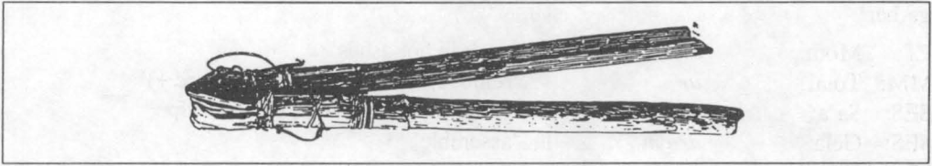

**Figure 21:** POc *kapit ‘tongs’ (from Nevermann_1933: 102)

Lichtenberk adds a number of other terms which, as well as being used in relation to oven cooking, probably also have more general reference:

| **POc** |  | *taqo(n), *taqon-i- | ‘press down, weigh down with a weight, cover over with the cover weighed down; close a stone oven, (when earth or the last layer of leaves has been placed on top)’ |
| --- | --- | --- | --- |
| NNG | Mangap | *to* | ‘cook with hot stones; bake’ |
| NNG | Kove | *ta-tao* | ‘cook in a native oven’ |
| MM | Nakanai | *taho(robo)* | ‘put stones on top of the oven (over the bundled food)’ (*robo* ‘cover’) |
| SES | Gela | *tao* | ‘be face down, flat on face; (leaves in cooking) be on oven’ |
| NCV | Lewo | *toni* | ‘cook on hot stones; bake’ |
| NCV | Nguna | *taoni* | ‘bake in earth oven’ |
| Mic | Kiribatese | *taon-* | ‘press down, apply weight on’ |
| Mic | Marshallese | *cōn* | ‘press down on’ |
| Fij | Rotuman | *fao* | ‘cook and keep overnight for use next day’ |
| Pn | Tongan | *taʔo* | ‘bake’ |
| Pn | Tongan | *taʔo-taʔo* | ‘put a weight on to hold down’ |
| Pn | Tikopia | *tao* | ‘cover over, press down (oven +); bake food (from technique of covering earth oven with leaf pads in cooking)’ |
| Pn | Māori | *tao* | ‘cook in earth oven; weigh down’ |

| **PMP** |  | *bu(ŋ)kas | ‘expose, unveil’ (Blust 1983–84a) |
| --- | --- | --- | --- |
| **POc** |  | *puke(s), *pukes-i- | ‘uncover, open (stone oven; probably other things as well)’ |
| MM | Nakanai | *pue* | ‘remove food from the oven and open the bundle for eating; open any k.o. bundle; to prepare any food for eating (as by boning fish)’ |
| SES | Ulawa | *huʔesi* | ‘open (native oven); turn (pages of book)’ |
| SES | Sa’a | *huʔesi* | ‘open a native oven’ |
| NCV | Paamese | *vue* | ‘unwrap, unfold (leaves covering cooked pudding)’ |
| Fij | Rotuman | *huʔe* | ‘uncover’ |
| Fij | Bauan | *vuke* | ‘uncover’ |
| Pn | Tongan | *fuke* | ‘open up (native oven)’ |
| Pn | East Futunan | *fuke* | ‘uncover (earth oven +)’ |
| Pn | Māori | *huke* | ‘uncover (esp. earth oven)’ |

| **PMP** |  | *uruŋ | ‘collect, gather’ (Blust 1972b) |
| --- | --- | --- | --- |
| **POc** |  | *uru(ŋ) | ‘take food and/or hot stones out of stone oven or fire’; ‘collect, gather’ (more generally) |
| PT | Motu | *uru* | ‘cook in hot ashes’ |
| MM | Tolai | *ur* | ‘remove, take away (food off fire +)’ |
| SES | Sa’a | *uru-uru* | ‘gather up in the hand, collect, wipe’ |
| SES | Gela | *uruvu* | ‘assemble’ |
| Mic | Carolinian | *ɨrɨ* | ‘drag (s.t.), pull it’ |
| Mic | Woleaian | *iuz-iuz* | ‘drag, pull’ |
| Pn | Tongan | *ū* | ‘spread out the hot stones in a native oven before putting food on them’ |
| Pn | Samoan | *ulu-ulu* | ‘clear the stones from the hearth (before lighting up an oven)’ |
| Pn | Rapanui | *uru* | ‘take out the stones that have been heated in the earth oven; stick used for same’ |

Only certain kinds of stones are suitable for use in stone ovens. Although some terms for these have been located, e.g. Sudest (PT) *ɣərumu* ‘cooking stones used for mumu’, Sursurunga (MM, New Ireland) *kor* ‘kind of black stone used for mumuing’, no cognates are identifiable.

## 3. Cooking methods

Lichtenberk quotes from Oliver (1989:49) who has this to say about traditional cooking in Oceania: “Most cooking was by broiling, by boiling (where there were clay pots, which was not everywhere), and by baking (which was done in earth-pit ovens containing heated stones.)” Lichtenberk continues (p.270): “In some places, food is boiled not over fire but by means of hot stones dropped into a wooden bowl that contains the food and some liquid. Food can also be steamed. In baking and roasting, the food is often, though not necessarily, wrapped, usually in leaves, sometimes in bark.”

He has listed terms for a range of cooking methods, with a word of warning as to the reliability of precision in English glosses (‘roast’, ‘grill’, ‘broil’, ‘cook in fire’ etc.). He writes (p.273), “Even though more than one term for roasting may be reconstructable for POc, the differences in the glosses for the witnesses most likely reflect differences in the English backgrounds of the authors rather than differences in cooking methods.”

### 3.1. Cooking in stone oven

| **PEOc** |  | *papi- | ‘cook in oven with hot stones and leaves’ (cf. PEOc *papia ‘firewood, fuel’ with cognates in Mic. and Pn.) |
| --- | --- | --- | --- |
| SES | Lau | *fafi* | ‘put leaves on oven in cooking’ |
| SES | Kwaio | *fafi* | ‘cook in leaf oven’ |
| SES | ’Are’are | *hahi-* | ‘cook between hot stones’ |
| SES | Arosi | *hahi* | ‘cook in native oven (umu)’ |
| Fij | Bauan | *vavi-* | ‘bake food in native oven (lovo)’ |

Lichtenberk also gives a reconstruction, *biti ‘cook with hot stones (either by baking in stone oven, or by boiling by dropping hot stones into liquid)’ (p.271), which he suggests may be POc, although he points out that all cognates are from either Northwest or Southeast Solomonic languages, and thus likely candidates for borrowing. We have opted here to label his reconstruction PSS.

### 3.2. Roasting, burning, branding

| **PAn** |  | *CuNuh | ‘roast food over a fire’ (ACD) |
| --- | --- | --- | --- |
| **POc** |  | *tunu | ‘roast on embers or in fire; burn (s.t.); make decorative cicatrices by burning the skin’ |
| Adm | Wuvulu | *unu* | ‘cook, roast’ |
| NNG | Wogeo | *tunu* | ‘roast, burn; cook it!’ |
| NNG | Gedaged | *tun(i)* | ‘cause to burn, light (a fire so it burns well), set fire’ |
| NNG | Sengseng | *tun* | ‘burn; burn shells or limestone to make lime; burn cicatrices; set fire to’ |
| PT | Minaveha | *tunu* | ‘roast, burn, ignite’ |
| PT | Motu | *tunu-* | ‘bake pottery’ |
| MM | Tolai | *tun* | ‘burn, cook, roast, broil’ |
| MM | Roviana | *tunu* | ‘burn scars on the arm (as is often done by young boys)’ |
| MM | Maringe | *tunu* | ‘burn with fire’ |
| SES | Bugotu | *tunu* | ‘a mark, blot, cicatrice caused by burning’ |
| SES | Tolo | *tunu* | (1) ‘light lamp or fire’; (2) ‘burn the skin to make raised scar tissue’ |
| SES | Sa’a | *ūnu-unu* | ‘burn in the fire, roast flesh on the embers; raise cicatrices on the body by burning’ |
| NCV | Mota | *tun* | ‘roast on or over embers’[^3] |
| NCal | Nemi | *cini* | ‘burn, grill in fire’ |
| Mic | Kiribatese | *tin-tin* | ‘grill or roast on open fire’ |
| Fij | Bauan | *tunu* | ‘warm food up again’ |
| Pn | Tongan | *tunu* | ‘cook on open fire’ |
| Pn | Takuu | *tunu* | ‘cook on hot coals, roast’ |
| Pn | Hawaiian | *kunu* | ‘broil (meat, fish +) on coals’ |

| **POc** |  | *mʷaRi | ‘roast, burn’ (Grace 1969) [^4] |
| --- | --- | --- | --- |
| NNG | Gedaged | *mazi* | ‘roast, cauterize, toast, bake, parch, sear, burn, incinerate, set fire to ignite, light (a cigar)’ |
| NNG | Takia | *mari* | ‘roast on fire’ |
| NNG | Manam | *moa-moari* | ‘cook in fire, roast, burn, singe’ |
| SES | ’Are’are | *mari-ʔa* | ‘cooked, roasted’ (*-ʔa* from adjectiviser *-ka) |
| Mic | Kiribatese | *mʷai* | ‘cooked, well done’ (Geraghty 1990) |

### 3.3. Piercing, pricking

When food was roasted, instead of simply being placed in the fire, it may have been skewered. The terms referring to skewering and skewers were also used to refer to testing food by pricking to see whether it was done. (See PMP *cukcuk, *suksuk* ‘skewer’, and POc *(su)su(k) ‘anything used to pierce, prick, a skewer’; *(su)suk-i- ‘pierce, prick’; Ch. 4, §3.2.1 and Ch. 9, §4.1).

### 3.4. Boiling, steaming

Two verbs are reconstructable for POc with the meaning ‘boil’. The problem is that the sources of data do not usually distinguish between boiling and steaming, both of which are practised in Oceania, ‘boil’ being the usual gloss. The difference between boiling and steaming lies in the amount of liquid used. For boiling, the food is (more or less) entirely covered with the liquid; for steaming, only a small amount of liquid is used. If POc did have a lexical distinction between the two processes, there is some evidence, albeit weak, that the verb for ‘boil’ was *nasu and that the one for ‘steam’ was *napu, It is also conceivable that of the two terms, *nasu was unmarked and could be used to refer to both types of process.

| **PAn** |  | *nasuk, *Nasu | ‘cook by boiling’ (ACD) |
| --- | --- | --- | --- |
| **POc** |  | *nasu(q) | [V] ‘boil; steam (?)’ |
| NNG | Gitua | *na-nazu* | ‘cook in hot water’ |
| PT | Maopa | *naru* | ‘boil (s.t.)’ |
| PT | Motu | *nadu-* | ‘cook by boiling’ |
| PT | Motu | *na-nadu* | ‘cook (general term)’ |
| MM | Petats | *nös* | ‘cook by boiling’ |
| MM | Teop | *nahu* | ‘cook; pot’ |

| **POc** |  | *napu | [v] ‘steam (?), boil (?)’ |
| --- | --- | --- | --- |
| NNG | Kairiru | *nau* | ‘cook, boil in a saucepan (plural object)’ |
| NNG | Gedaged | *nai* | ‘cook, boil’ |
| Fij | Bauan | *navu* | ‘cook in steam’ |

It is possible that the forms attributed to PPT *na(q)u(q) ‘clay dish’ in Chapter 4, §2.1.5, are also reflexes of *napu: see the discussion there.

### 3.5. Warming

Lichtenberk contributes a POc term which he glosses as ‘warm oneself by fire; warm up, reheat (esp. food)’. Ann Chowning has added cognates from Kove, Molima and Nakanai which, like the Pukapuka term, refer to heating of leaves in preparation for mat making (see Chapter 4, §3.1.1).The POc gloss has been generalised accordingly.

| **PAn** |  | *da(n)daŋ | ‘heat s.t. or warm oneself by fire’ (Dempwolff 1938) |
| --- | --- | --- | --- |
| **POc** |  | *raraŋ, *raŋ-i- | ‘heat s.t. or warm oneself by fire’ |
| NNG | Manam | *raraŋ* | ‘warm up (food that has become cold), warm up again’ |
| NNG | Kove | *lala* | ‘wilt pandanus leaves over a fire in order to soften them for mat making’ |
| NNG | Numbami | *lalaŋi* | ‘singe, scorch’ |
| PT | Molima | *lala* | ‘wilt pandanus leaves over a fire in order to soften them for mat making’ |
| MM | Nakanai | *lala* | ‘wilt pandanus leaves over a fire in order to soften them for mat making’ |
| SES | Gela | *raraŋ(asi)* | ‘dry up by heat’ |
| SES | Sa’a | *ra-raŋi* | ‘warm oneself at the fire’ |
| NCV | Mota | *raŋ(ai)* | ‘roast or bake over embers, without a wrapper’ |
| NCV | Raga | *ra-raŋi* | ‘roast on embers’ |
| SV | Kwamera | *(a)rəŋi* | ‘singe, burn (hair off pig), warm, dry by fire’ |
| Mic | Mokilese | *rɔŋ-rɔŋ* | ‘warm oneself’ |
| Mic | Marshallese | *raŋ-raŋ* | ‘warm oneself by the fire’ |
| Fij | Rotuman | *rara* | ‘warm, toast’ |
| Fij | Bauan | *ra-raŋ-* | ‘warm oneself at a fire; of pain, smart slightly’ |
| Fij | Bauan | *(vaka)ra-raŋ-* | ‘warm food again by placing it near a fire; sear up banana leaves around food’ |
| Pn | Pukapukan | *lala* | ‘bleach pandanus leaves by passing them over a fire’ |
| Pn | Hawaiian | *lala* | ‘warm up, cook over fire; warm oneself by a fire’ |

cf. also:

| Pn | Tongan | *lala* | ‘half-cook, cook lightly (fish)’ |
| --- | --- | --- | --- |

### 3.6. Singeing

A term can be reconstructed for the action of singeing food in preparation for cooking:

| **POc** |  | *sunu | ‘singe’ |
| --- | --- | --- | --- |
| Adm | Loniu | *sun* |  |
| Adm | Nyindrou | *sun* | ‘burn or cook (over fire); roast’ |
| PT | Kilivila | *sulu-sulu* | ‘cook’ |
| MM | Nakanai | *sulu-lu* |  |
| Mic | Marshallese | *tʷini-y* |  |
| Fij | Rotuman | *su-sunu* | ‘burn, scorch’ |
| Pn | Tongan | *hunu* |  |
| Pn | Tuvalu | *hunu-hunu* | ‘cook fish or fowl in flames’ |
| Pn | Māori | *hu-hunu* |  |

### 3.7. Wrapping prior to oven-cooking

Two similar terms for wrapping food for cooking (baking or roasting), POc *kapu(t), *kaput-i- and POc *kopu, have been reconstructed. Mills (1981: 73) has proposed PMP *kaput ‘close, cover’, while Blust (1986:45) gives a gloss of ‘tie or clasp together’ for an identical PMP reconstruction. Oceanic reflexes indicate two distinct terms, although there may have been some blending of meaning in daughter languages. Lichtenberk suggests that the two POc terms may have referred to different ways of wrapping food; Firth (1957), for instance, gives four terms for different ways of wrapping food in Tikopia. From the glosses below, it seems possible that *kapu(t), *kaput-i- referred to covering (as an earth oven is covered), whilst *kopu referred to the wrapping of the food in bundles. For both terms, reflexes indicate wider reference than to food alone. In Polynesia they have come to refer more specifically to clothing or blankets.

| **PMP** |  | *kaput | ‘close, cover’ (Mills 1981) |
| --- | --- | --- | --- |
| **POc** |  | *kapu(t), *kaput-i- | ‘wrap, cover; cover food prior to cooking’ (Lichtenberk has *apu) |
| NNG | Manam | *avu* | ‘wrap up, bandage’ |
| PT | Motu | *ahu* | ‘closed’ |
| MM | Nakanai | *avu* | ‘wrap s.t. up (e.g. *avu-kalebu* - wrap up fish for cooking so that pieces of fish are separated by a layer of leaves)’ |
| MM | Kara (East) | *ɣəfute* | ‘cover’ |
| SES | Lau | *ʔafu* | ‘wrap up; make a cigarette’ |
| SES | To’aba’ita | *ʔafu* | ‘wrap s.t. (e.g. wrap fish—not pork—in a leaf for cooking)’ |
| SES | ’Are’are | *ʔahu* | ‘wrap, cover’ |
| SES | Arosi | *ahui-* | ‘wrap up’ |
| SES | Arosi | *ahu(nu)* | ‘broil on the embers in a leaf’ |
| SES | Bauro | *(gin)ahu* | ‘wrap up in leaves’ |
| NCV | Raga | *gavus* | ‘wrap, cover, cook on embers in wrapper’ |
| **PPn** |  | *kafu | [N] ‘clothing or covering for the body’; [V] ‘cover the body’ |
| Pn | Niuean | *kaputi* | ‘overspread, cover the whole surface’ |
| Pn | Tongan | *kafu* | ‘cover oneself; clothing’ |
| Pn | Samoan | *ʔafu* | [V] ‘draw (sheet + over the body)’; [N] ‘fine mats for presentation’ |
| Pn | Tikopia | *kafu* | ‘blanket, traditionally of bark-cloth; clothing’ |
| Pn | Tahitian | *ʔahu* | ‘cloth, clothing; bark-cloth’ |
| Pn | Hawaiian | *ʔahu* | ‘covering (for the upper part of the body); fine soft mat often used as body covering’ |
| Pn | Māori | *kākahu* | ‘clothing’ |

| **POc** |  | *kopu | [v] ‘wrap (food in a certain way (?) for cooking), bundle, wrap’ (Lichtenberk) |
| --- | --- | --- | --- |
| MM | Nakanai | *kobu* | ‘cigarette; leaves wrapped around pork to be cooked with it’ |
| SES | Gela | *ovu* | ‘crowd, heap, pile, flock; assemble, heap together, make a bundle; a bundle’ |
| SES | Lau | *ofu* | ‘be together’ |
| SES | Arosi | *ʔohu* | ‘cook with hot stones; boil; put together, rake together (fire)’ |
| Fij | Wayan | *kovu* | ‘be covered, wrapped’ |
| Fij | Wayan | *(i)kovu* | ‘parcel, bundle’ (*i-* < POc *i- INS) |
| Fij | Bauan | *kovu* | ‘tie up vakalolo (k.o. pudding) or fish in banana leaves’ |
| **PPn** |  | *kofu | [N] ‘clothing; leaf-wrapped parcel of food’; [V] ‘wrap food in leaves’ |
| Pn | Tongan | *kofu* | ‘wrap up; garment, clothing, dress’ |
| Pn | Tongan | *kofu-kofu* | ‘parcel, bundle’ |
| Pn | Samoan | *ʔofu* | ‘garment, dress, clothes; food done up in a small bundle of leaves (for cooking in stone oven or for convenience)’ |
| Pn | Samoan | *ʔofu-ʔofu* | ‘wrap food up in leaves ready for cooking’ |
| Pn | East Futunan | *kofu-kofu* | ‘parcel of cooked food’ |
| Pn | West Uvean | *kofu* | ‘garment’ |
| Pn | Rennellese | *kohu* | ‘package of roasted or baked food, with leaves’ |
| Pn | Tikopia | *kofu* | ‘make package in leaf or cloth, tied at top; leaf/cloth package usually containing soft food’ |

### 3.8. Uncooked food

Lichtenberk also considers terms for uncooked food. He proposes a general POc term *(a)mataq for raw food (possibly excluding certain foodstuffs) which also refers to unripe foodstuff, such as fruit. Its reflexes in fact seem to reflect two forms, *mataq and *qa-mataq, the latter presumably derived from the former, but the function of *qa- is unclear.

| **PAn** |  | *ma-qataq | ‘raw, unripe’ (ACD) |
| --- | --- | --- | --- |
| **POc** |  | *mataq | ‘raw, unripe, new, green’ (ACD) |
| NNG | Tami | *mata* | ‘green’ |
| NNG | Dami | *mata* | ‘green, unripe’ |
| NNG | Yabem | *mataʔ-mataʔ* | ‘green’ |
| NNG | Yabem | *mataʔ* | ‘young’ |
| NNG | Kairiru | *mataq* | ‘unripe, raw’ |
| MM | Kara (East) | *matak* | ‘not ready, not ripe’ |
| MM | Tabar | *magat(i)* | ‘raw’ |
| MM | Madak | *makat* | ‘new’ (metathesised) |
| MM | Siar | *metek* | ‘new’ |
| MM | Roviana | *makata* | ‘unripe’ (metathesised) |
| SES | Gela | *mata-mata* | ‘(domesticated animals +) wild, shy, timid’ |
| SES | Kwaio | *maʔa* | ‘raw’ |
| NCV | Paamese | *mete(s)* | ‘raw, uncooked’ |
| NCV | Nguna | *mata* | ‘raw, unripe, (wood) green’ |
| SV | Kwamera | *(a)mera* | ‘uncooked, raw; (land) fertile’ |
| SV | Kwamera | *(a)mrɨ-mera* | ‘green, light blue; raw, uncooked’ |
| SV | Anejom̃ | *mat* | ‘raw’ |
| NCal | Xârâcùù | *mata* | ‘raw, green (not ripe), new (unused)’ |
| Mic | Kiribatese | *mata* | ‘undercooked’ |
| Fij | Rotuman | *mafa* | ‘raw, uncooked; green, undried’ |
| Pn | Tongan | *mata* | ‘(fruit) green, unripe, or raw; (copra) undried; (timber) unseasoned, or not thoroughly seasoned’ |
| Pn | Samoan | *mata* | ‘raw, unripe’ |

| **PAn** |  | *qamataq | ‘raw, uncooked’ (ACD) |
| --- | --- | --- | --- |
| **POc** |  | *qamataq | ‘not ready to be eaten (because unripe or raw)’ (Lichtenberk) |
| NNG | Lukep (Pono) | *gamata-na* |  |
| NNG | Manam | *amata-mata* | ‘raw, uncooked’ |
| Mic | Kiribatese | *amata* | ‘not cooked enough, half raw; half-cooked food’ |
| Mic | Ponapean | *amas* | ‘raw, uncooked’ |
| Mic | Woleaian | *yemata* | ‘raw, not cooked; new’ |

PAn/PMP *maqataq evidently consisted of *ma- ‘anticausative’ (Ch. 2, §3.1.2) + *qataq* ‘eat something raw’. The POc reflex *mataq shows irregular loss of medial *-q-. The unaffixed base also survived in POc, and is reflected, with meanings similar to *mataq, in some Oceanic languages.

| **PAn** |  | *qataq | ‘eat s.t. raw’ (ACD) |
| --- | --- | --- | --- |
| **POc** |  | *qata(q) | ‘Young, raw’ |
| NNG | Dami | *ata* | ‘green’ |
| NNG | Yabem | *ataʔ-ataʔ* | ‘green’ |
| PT | Motu | *ata-ata* | ‘young’ |
| NCal | Xârâcùù | *ata* | ‘new’ |

Alongside *qataq, PAn also had a term *qetaq, which retained its verbal use in POc, referring specifically to raw meat, fish and shellfish, and to the eating of such foods:

| **PAn** |  | *qetaq | ‘eat s.t. raw’ (ACD) |
| --- | --- | --- | --- |
| **POc** |  | *(k,q)oda | ‘raw (meat, fish, shellfish); eat raw (meat, fish, shellfish)’ |
| PT | Molima | *oda* | ‘(animals) eat raw food’ |
| PT | Kilivila | *koda* | ‘eat s.t. uncooked’ |
| MM | Roviana | *oda* | ‘eat fish without baso (relish) or vegetables; eat garden produce, of pigs’ |
| SES | Gela | *ada* | ‘eat raw; (animals) destroy a garden’ |
| SES | Kwaio | *oda* | ‘eat raw; (Pig) eat a garden’ |
| Mic | Kiribatese | *ora-ora* | ‘act of eating fish or meat in a raw state’ |
| Mic | Kosraean | *oṣe* | ‘eat raw’ |
| Mic | Puluwatese | *wor-* | ‘possessive classifier for raw food; raw seafood, meat (cooked or raw), eggs’ |
| Fij | Bauan | *koda* | ‘eat raw meat’ |
| Pn | Tongan | *ʔota* | ‘raw, uncooked -mostly of meat, fish, shell-fish, or eggs; eat raw fish or shell-fish’ |
| Pn | Nanumean | *ota* | ‘raw fish or fruit; eat fish raw’ |
| Pn | Rarotongan | *ota* | ‘any raw flesh such as raw fish; raw, green, uncooked’ |

### 3.9. Food cooked or ripe

Similarly, the term for ‘cooked’ also meant ‘ripe’; both glosses could be subsumed as ‘ready to be eaten’.

| **PMP** |  | *(ma-)qesak | ‘ripe, cooked, ready to eat’ (ACD) |
| --- | --- | --- | --- |
| **POc** |  | *ma-osak | ‘ready to be eaten (because ripe or cooked)’ |
| Adm | Lou | *mʷas* | ‘cooked’ |
| PT | Motu | *maeda* | ‘(things cooked) be done’ (sporadic fronting of POc *o) |
| MM | Nakanai | *maosa* | ‘cooked, done, ripe’ |
| MM | Bali | *mazaka* | ‘cooked, ripe’ |
| MM | Teop | *mahaka* | ‘cooked’ |
| SES | ’Are’are | *mata* | ‘(fruit) ripe’ |
| SES | Gela | *mo-moha* | ‘(food) cooked’ |
| SES | Lengo | *matak* | ‘ready to be eaten, ripe, cooked, done’ |
| NCV | Paamese | *maso* | ‘cooked’ |
| NCV | Nguna | *māso* | ‘cooked; cooked, burned’ |
| Mic | Marshallese | *matʷ* | ‘cooked’ |
| Fij | Rotuman | *ma-mosa* | ‘cooked, ripe’ |
| Pn | Tongan | *moho* | ‘cooked, fully cooked, done’ |

Another term with meaning similar to *maosak stresses the good quality of the food:

| **POc** |  | *[ma]noka | ‘be in good condition for eating: nicely ripe, well-cooked, soft’ |
| --- | --- | --- | --- |
| NNG | Manam | *noʔa* | ‘ripe, esp. when soft; overripe; done, cooked’ |
| PT | Kilivila | *monogu* | ‘ripe’ |
| NCV | Mota | *manoga* | ‘cooked, well-done’ |

## 4. Preserving

Lichtenberk (p.277) records two main ways of preserving food in Oceania. One is drying, either in the sun or above fire (the latter may involve smoking the food); the other is fermentation.

### 4.1. Drying, smoking

| **PAn** |  | *Capa | [V] ‘smoke fish or meat for preservation’ (ACD) |
| --- | --- | --- | --- |
| **POc** |  | *tapa | [V] ‘dry food by heat to preserve it; smoke food’ (Lichtenberk) |
| MM | Roviana | *tava* | ‘cook or dry (fish, copra +) by smoking or heating’ |

In addition, Blust offers the following:

| **PMP** |  | *pa[ka]-qasu | [v] ‘smoke, fumigate’ (from *pa[ka] ‘causative’ + PMP *qasu (N) ‘smoke, fumes, steam’); [v] ‘(fire) smoke’ (ACD) |
| --- | --- | --- | --- |
| **POc** |  | *pa[ka]-qasu | [V] ‘smoke, cure by smoking’ |
| Mic | Trukese | *ātɨ* | [V] ‘smoke, steam; cause to be smoked or steamed (for curing)’ |
| Fij | Rotuman | *fak-asu* | ‘place in smoke’ |
| Pn | Tongan | *faka-ʔahu* | ‘preserve by smoking etc.’ |
| Pn | Samoan | *faʔ-asu* | [V] ‘smoke (fish or meat); fumigate’ |

Malcolm Ross (pers.comm.) reconstructs:

| **PNGOc** |  | *pa(r,R)a | [V] ‘dry by smoking’ |
| --- | --- | --- | --- |
| NNG | Lukep | *para* |  |
| NNG | Mangap | *pāra* |  |
| PT | Iduna | *vala-* |  |

### 4.2. Fermentation

Fermentation of food is geographically much more restricted. Small islands, particularly atolls, are susceptible to food shortages as a result of drought or prolonged stormy weather which makes fishing impossible, and have greater need for food reserves. Food fermentation is practised primarily in those areas where sago is not available as a staple, the latter being easily stored for lengthy periods of time. Assuming that sago was available as a foodstuff in POc times (see Dutton 1994), Lichtenberk argues (p.278) that the nearly complementary distribution of sago as a staple and fermented foodstuff suggests that the presence of fermentation in Micronesia and Polynesia is due to independent developments. Also relevant, however, is the fact that fermented breadfruit is regarded as one of the few foods suitable for carrying on longer sea voyages, and thus a prime suspect, along with its term, for borrowing. Yen (1975) writes that in Melanesia fermentation appears to be practised only in Santa Cruz and ascribes its presence there to Polynesian influence. However, David Walsh has pointed out (pers.comm. with Lichtenberk) that fermentation is practised also in some areas in Vanuatu. (See the Namakir form *mada* below.) Ross (Food plants, vol. 3) points out that there is a curious cross-over between the reflexes of PEOc *mara ‘preserved breadfruit’ and POc *madraR ‘grow ripe, overripe’, *madraR-i- ‘grow ripe, overripe from (s.t.) (?)’. In scattered languages in Vanuatu, Fiji and Micronesia, a reflex of *madraR/*madraR-i- has taken over the ‘preserved breadfruit’ sense which we would instead expect to find associated with a reflex *mara. Since closely related languages both in Vanuatu and in Micronesia disagree as to which term they reflect, Ross infers that the closeness of both form and meaning has led to confusion between the two terms, leading to more than one independent occurrence of crossover. POc *madraR seems to have been applied specifically to breadfruit and bananas, both of which become soft and mushy when overripe. Breadfruit and bananas are also the two foodstuffs which today are most commonly preserved by fermentation (Yen 1975). Chowning lists a Nakanai cognate which indicates that the original POc term may have meant simply ‘be spoiled (of food or drink)’, with its meaning narrowing in Eastern Oceanic.

| **POc** |  | *mara | ‘be spoiled, foul (of food or drink)’ |
| --- | --- | --- | --- |
| MM | Nakanai | *mala (gari)* | ‘not good to drink, of water’ (*gari* ‘bite into’) |
| SES | Kwaio | *malā* | ‘be spoiled, foul’ |
| SES | Lau | *marā* | ‘be spoiled, foul’ |
| NCV | Raga | *mara* | ‘preserved breadfruit’ |
| NCV | Uripiv | *na-mer* | ‘preserved breadfruit’ |
| NCV | Paamese | *a-mē* | ‘preserved breadfruit’ |
| NCV | Tamambo | *mara* | ‘preserved breadfruit’ |
| SV | Anejom̃ | *na-marai* | ‘preserved breadfruit’ |
| Mic | Kosraean | *mæer* | ‘core of a preserved breadfruit’ |
| Mic | Mokilese | *mar* | ‘preserved breadfruit’ |
| Mic | Trukese | *mara-* | ‘preserved breadfruit’ |
| Mic | Woleaian | *māza* | ‘preserved breadfruit’ |
| Fij | Rotuman | *mara* | ‘preserved starchy food’ |
| Fij | Wayan | *mara* | ‘stink, be rotten’ |
| Pn | Tongan | *mā* | ‘ensilage (for human consumption), usually plantain or banana, stored in pit’ |
| Pn | Ifira-Mele | *mara* | ‘breadfruit, taro or banana preserved by fermenting in a pit’ |

| **POc** |  | *madraR | ‘grow ripe, (breadfruit and bananas) be overripe’ |
| --- | --- | --- | --- |
| **POc** |  | *madraR-i- | ‘grow ripe, overripe from (s.t.) (?)’ |
| Adm | Mondropolon | *madra-n* | ‘ripe’ |
| NNG | Bilibil | *mad* | ‘ripe’ |
| MM | Tolai | *madar* | ‘ripe, overripe’ |
| MM | Nakanai | *malalaso* | ‘ripe, of fruit such as bananas’ |
| SES | Gela | *mada* | ‘ripe’ |
| SES | Gela | *madari* | ‘(banana +) overripe’ |
| SES | Arosi | *mada* | ‘be ripe’ |
| SES | Arosi | *madari* | ‘grow ripe from’ |
| NCV | Namakir | *mada* | ‘preserved breadfruit, manioc +’ |
| NCV | Nguna | *na-madai* | ‘preserved breadfruit, manioc +’ |
| Mic | Marshallese | *mmeṛ* | ‘(breadfruit only) very ripe, overripe’ |
| Fij | Wayan | *madra* | ‘(fruit) be very ripe, overripe but still good’ |
| Fij | Bauan | *madrai* | ‘Fijian bread, rolls/loaves of breadfruit buried in the ground for months’ |

Other terms which in parts of Polynesia refer to fermented breadfruit are derived from POc *maqasin.

| **PAn** |  | *qasin | ‘salty’ (Zorc 1994) |
| --- | --- | --- | --- |
| **POc** |  | *ma-qasin | ‘be salty, sharp, of taste’ |
| Adm | Mussau | *masini* | ‘salty’ |
| NNG | Sengseng | *masi* | ‘tasty, sweet’ |
| NNG | Gedaged | *mas* | ‘salt water; salt’ |
| MM | Nakanai | *ma-masi* | ‘salty; stinging, as salt water in a wound’ |
| Fij | Rotuman | *masi* | ‘salt’ |
| Fij | Bauan | *masi(ma)* | ‘salt obtained by evaporation from seawater’ |
| Fij | Bauan | *masi-masi(a)* | ‘prematurely spoiled by the south wind, of breadfruit’ |
| Pn | Tongan | *mahi* | ‘sour, astringent’ |
| Pn | Samoan | *masi* | ‘breadfruit left to ferment in a special pit’ |
| Pn | Tahitian | *mahi* | ‘acid, fermented; breadfruit preserved by fermenting’ |

## 5. Food processing

### 5.1. Pounding

We have terms for the action of pounding or crushing, but have been unable to reconstruct any term for the implement or implements involved apart from PWOc *walu ‘sago beater’ and POc *ike ‘(bark-cloth) beater’ (for the latter, see Ch. 4, §S . l).

| **PWOc** |  | *walu | ‘sago beater’ (Chowning 1991) |
| --- | --- | --- | --- |
| NNG | Kove | *walu* |  |
| PT | Molima | *(e)wanu* | (*e-* < PPT *kai- INS) |
| MM | Nakanai | *ualu* |  |

> Pounded foods are widespread in Oceania (Yen 1975). In Pidgin and in English they are referred to as ‘puddings’ (although not all puddings require pounding). The usual main ingredient is tubers (taro, yam), cooked and pounded, mashed into a paste together with other ingredients such as coconut cream or nuts, and then usually recooked.

A large wooden bowl (POc *tabiRa, PCP *kumete, see Ch. 4, §2.2.1) was traditionally used as a mortar. Sago was pounded in a trough, stronger and heavier than a bowl, and designed so that water could run off from one end. Only isolated terms have been located (Muyuw *kas* ‘trough for sago-making’; Loniu *kupʷi* ‘trough in which sago is pounded’).

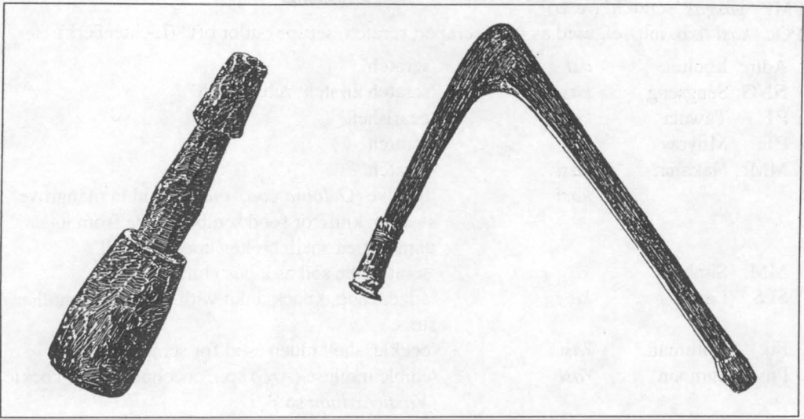

**Figure 22:** taro stamper (no reconstruction) (from Nevermann_1934: 192) PWOc *walu ‘sago beater’ (from Nevermann_1934: 174)

As Blust (ACD) notes, terms dealing with the action of pounding frequently contain the root *-tuk. A number of reconstructions have been made which evidently refer to hitting, pounding, beating, breaking open, and so on, not just of foodstuffs, but with general application. Cognate sets for the following reconstructions are included in Chapter 9, §5.1: POc *tutuk ‘pound, mash by pounding, hammer, crack by hammering’ (from PAn *tuqtuq); POc *tuki- ‘pound’; POc *putu(k) ‘knock, pound, beat’ (ACD) (from PMP *buTuk); and POc *qatuŋ-i ‘strike from above, pound’.

### 5.2. Grating, scraping

Foodstuffs such as tubers and coconut meat are often grated before further processing. Tubers also need to be scraped to remove dirt. Both processes can be carried out with a shell such as a cockle, and the scraper/grater may be referred to by its shell name. Scrapers and graters are not always separately identified. The same implement may serve both functions, just as the same verb may refer to both actions.

| **PMP** |  | *kuDkuD | ‘rasp, file’ (Blust 1972b) |
| --- | --- | --- | --- |
| **POc** |  | *kuku(r) | ‘mussel; grater made of mussel shell’ |
| NNG | Takia | *kuk* | ‘kind of shellfish: *Anadara*, cockle shell’ |
| NNG | Kove | *kuku* | ‘a mussel’ |
| Fij | Bauan | *kuku* | ‘k.o. mussel (used as a grater)’ |
| Pn | Samoan | *ʔuʔu* | ‘mollusc, the shell of which is used by women to split pandanus leaves’ |
| Pn | Marquesan | *kuku* | ‘prepare strips of pandanus for mats, hibiscus bark for cord’ |
| Pn | Tikopia | *kuku* | ‘grate (turmeric)’ |

| **PMP** |  | *gasgas | ‘scratch’ (ACD) |
| --- | --- | --- | --- |
| **POc** |  | *kasi | ‘k.o. mussel, used as food scraper; scratch, scrape out or off’ (Lichtenberk) |
| Adm | Loniu | *asi* | ‘scratch’ |
| NNG | Sengseng | *kas* | ‘scratch an itch; rub; to itch’ |
| PT | Tawala | *kahi* | ‘pearlshell’ |
| PT | Muyuw | *kas* | ‘scratch’ |
| MM | Nakanai | *kasi* | ‘scratch’; ‘bivalve (*Geloina coaxans*), found in mangrove swamp; knife or food scraper made from its unmodified shell; broken coconut shell’ |
| MM | Simbo | *kasi-kasi* | ‘scratch the soil as a bush turkey’ |
| SES | Lau | *kasi* | ‘adze, chop; knock a nut with a stone on another stone’ |
| Fij | Rotuman | *ʔasi* | ‘cockle; shell much used for scraping’ |
| Pn | Samoan | *ʔasi* | ‘edible mollusc (*Arca* sp.); coconut scraper cockle (*Vasticardium* sp.)’ |
| Pn | Tikopia | *kasi* | ‘bivalve mollusc (*Asaphis violascens*), possibly other related bivalves also; shell traditionally used as cutting or scraping implement, as food scraper for coconut, breadfruit’ |

| **PEOc** |  | *kaRi | ‘scraper; bivalve sp., used as a scraper’ (Geraghty 1990) |
| --- | --- | --- | --- |
| SES | Gela | *gali* | ‘species mollusc, pelecypod, *Asaphis deflorata*, eaten’ |
| NCV | Mota | *gar* | ‘cockle’ |
| NCV | Mota | *(vin)gar* | ‘cockle shell, used to cut yam vines and to scrape out meat from coconut’ (vin from viniu ‘skin, bark, husk, partic. of coconut’) |
| Fij | Bauan | *kai* | ‘generic name of bivalve shellfish, Lamellibranchiata’ |

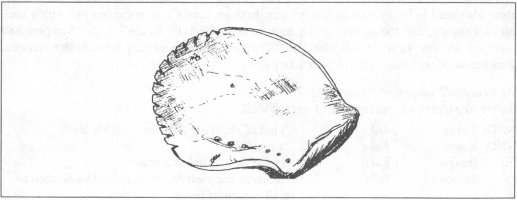

| **POc** |  | *kara(s), *karas-i- | ‘peel or scrape skin off tubers’ (Lichtenberk) |
| --- | --- | --- | --- |
| Adm | Mussau | *kalasi* |  |
| MM | Kara (West) | *kaias* |  |
| MM | Maringe | *ka-krasi* | ‘scrape off potato or taro skin, using a shell’ (also *kekesi*) |
| SES | Arosi | *karasi* | ‘scrape, bruise, take off skin’ |
| SES | Kwaio | *galā* | ‘peel skin off (vegetable +)’ |
| SES | Kwaio | *galasi-* | ‘peel a raw vegetable’ |
| SES | To’aba’ita | *garasi* | ‘scrape (taro, sweet potato + to remove dirt after pulling it out of ground)’ |
| SES | Sa’a | *kara, karasi* | ‘scrape, grate’ |
| SES | Sa’a | *kara (uhi)* | ‘grate yams with a cockle shell’ (*uhi* ‘yam’) |

A number of formally similar terms have been reconstructed for the action of scratching, scraping and grating. Although the reference is often primarily to preparation of foodstuffs, such terms are often used to refer to any similar action such as scratching the skin or scraping the bottom of a canoe.

| **PMP** |  | *karis | ‘scratch mark’ (ACD) |
| --- | --- | --- | --- |
| **POc** |  | *kari(s), *karis-i- | ‘scrape (tubers, coconuts)’ (Lichtenberk); ‘scratch a mark on s.t.’ |
| NNG | Kove | *karisi* | ‘scrape (one’s skin)’ |
| NNG | Akolet | *karis* | ‘scratch (one’s skin)’ |
| NNG | Labu | *kalê* | ‘scratch’ |
| PT | Motu | *ari-* | [V] ‘mark, indent (bottom of canoe with stones +)’ |
| MM | Bulu | *kari* | ‘scratch (one’s skin)’ |
| MM | Maringe | *kai-kari* | [VT] ‘scrape off (e.g. mud from one’s feet), remove with scraping action, usually with implement like a piece of bamboo’ |
| SES | Gela | *kari* | ‘scrape off (dirt from a cut +); scrape out (white of coconut)’ |
| SES | Gela | *karisi-* | ‘peel off (skin of stem of plant or stick); circumcise’ |
| SES | Tolo | *karisi-* | ‘peel (with knife, shell +)’ |
| SES | Arosi | *kari-kari* | ‘scrape off small roots with *waro* shell’ |
| SV | Anejom̃ | *(a)ɣreθ* | ‘scrape’ |
| Mic | Carolinian | *xeri* | ‘scratch s.t., grate it’ |
| Mic | Marshallese | *kar* | ‘scratch, scrape’ |
| Fij | Wayan | *kari* | ‘be scraped’ |
| Fij | Wayan | *(i)kari* | ‘grater’ (*i-* < POc *i- INS) |
| Fij | Bauan | *kari-* | ‘scrape (coconut +)’ |

| **POc** |  | *ko(r,R)a(s), *ko(r,R)as-i- | ‘scrape out (coconut meat); dregs of strained coconut scrapings’[^5] |
| --- | --- | --- | --- |
| SES | Arosi | *ʔora* | ‘scrape with a shell’ |
| SES | Arosi | *ʔorasi* | ‘dregs of strained coconut scrapings’ |
| NCV | Mota | *goras* | ‘scrape out, grate, the hard meat of coconut with cockle shell (*vin-gar*)’ |
| Mic | Carolinian | *xɨrɨ* | ‘scrape or grate’ |
| Fij | Bauan | *kora* | ‘refuse of scraped coconut’ |

| **POc** |  | *gora(s), *goras-i- | ‘scrape out (coconut meat +); dregs of strained coconut scrapings’ |
| --- | --- | --- | --- |
| MM | Maringe | *garosi* | ‘scrape, claw or scratch with one swipe’ (metathesis) |
| SES | Gela | *gola* | ‘scrape, plane’ |
| SES | Sa’a | *koras-i-* | ‘(rat +) scratch about’ |

| **POc** |  | *koRi | ‘scraper; bivalve sp., used as a scraper; scrape with a shell’ |
| --- | --- | --- | --- |
| NNG | Manam | *ʔori(ŋ)* | ‘scrape coconuts’ |
| NNG | Manam | *ʔori-ʔori* | ‘pearlshell, traditionally used to scrape coconuts; coconut grater, scraper’ |
| PT | Dobu | *koli* | ‘scrape, as coconut, wood’ |
| PT | Motu | *ori* | ‘grate coconut, chew pandanus fruit’ |
| MM | Vitu | *kori* | ‘scratch (one’s skin)’ |
| MM | Tabar | *kori-kori* | ‘scrape (coconut)’ |
| SES | Gela | *goli* | ‘scrape coconut with a tue (fresh water shell)’ |
| NCV | Nguna | *koi* | ‘grate (coconut)’ |
| Fij | Rotuman | *ʔoi* | ‘scrape, grate’ |
| Fij | Bauan | *koi* | ‘scrape (breadfruit)’ |
| Fij | Bauan | *(i)koi* | ‘shellfish’ |

| **POc** |  | *kori(s), *koris-i- | ‘scrape (esp. coconuts), grate (esp. coconuts)’[^6] |
| --- | --- | --- | --- |
| NNG | Kove | *ko-koli* | ‘scrape the exterior off food (trepang, taro)’ |
| SES | Gela | *goli* | ‘scrape coconut with a tue (fresh water shell)’ |
| SES | Gela | *gori* | ‘shave the head’ |
| SES | To’aba’ita | *kori* | ‘scrape (coconuts +)’ |
| SES | Tolo | *kori-* | ‘scrape or grate coconut’ |
| SES | Arosi | *ʔoris-i* | ‘scrape’ |
| NCV | Lewo | *koli* | ‘scrape (e.g. coconut)’ |

| **PCEMP** |  | *isi | ‘peel, strip off; scrape (coconut)’ (ACD) |
| --- | --- | --- | --- |
| **POc** |  | *isi | ‘scoop out (flesh from coconut +); peel off (skin, bark +)’ |
| NNG | Poeng | *isi* | ‘strip bark from tree or vine’ |
| PT | Molima | *isi, isi-* | ‘grate (on a grater), rub (s.t.)’ |
| PT | Motu | *idi* | ‘prise meat from coconut, press or squeeze with an implement’ |
| MM | Nakanai | *isi* | ‘scrape, grate (coconut); scrape wood smooth’ |
| Pn | Rennellese | *isi* | ‘scoop, scrape (coconut meat from shell)’ |

| **POc** |  | *rasi | ‘grate, scrape (tubers, coconuts); scratch’ (Lichtenberk: *(r,R)asik) |
| --- | --- | --- | --- |
| NNG | Manam | *rasiʔ* | ‘grate (cassava +)’ |
| NNG | Takia | *rasi* | ‘scrape (coconut)’ |
| MM | Banoni | *resi* | ‘scrape (coconut), coconut scraper’ |
| MM | Kia | *rahi* | ‘grate, scratch (coconut, cassava)’ |
| MM | Maringe | *(g)rahi* | ‘grate or scrape off (coconut or bark for making medicine +)’ |
| NCV | Mota | *ras* | ‘rub, scrape, scratch’ |
| NCV | Mota | *rasa* | ‘scrape, scratch, rub, with straight motions backwards and forwards; so, sharpen by rubbing backwards and forwards on a stone’ |
| NCV | Raga | *raha* | ‘grate, grind, sharpen’ |
| NCV | Lonwolwol | *rehe* | ‘rub, scrape, grate, grind’ |

Yet another reconstruction is POc *asa(q) ‘grate, sharpen by grating or rubbing’ from PAn *Sasaq ‘whet, sharpen’ (see Ch. 4, §4.1.S).

Lichtenberk comments (pp. 280-281) on the recurring sound symbolism evident in these items, a feature which Blust has identified with PAn forms meaning ‘rub, scrape, scratch’. Terms with similar sound symbolism readily undergo conflation. Lichtenberk also refers to the possibility that in POc or pre-POc times there was some kind of derivational relation among at least some of the forms, noting that unlike the other forms, *ko(r,R)as took as its direct object a noun phrase referring to the stuff scraped off rather than the object being scraped (e.g. the coconut meat rather than the coconut). (See also Ch. 9, §2.2.)

| **PEOc** |  | *paro(s), *paros-i- | ‘chafe (skin)’; ‘scrape’ |
| --- | --- | --- | --- |
| MM | Maringe | *poroji* | ‘chafe away the skin, e.g. tightly bound pig’s feet’ |
| SES | Lau | *faro* | ‘scraper for grating yams’ |
| NCV | Nguna | *vāro* | ‘chafing of inner thighs’ |
| NCV | Nguna | *varosi* | ‘grind (e.g. meat)’ |
| Fij | Wayan | *varoki* | [VT] ‘cut s.t. with a saw’ |
| Fij | Bauan | *varo* | [V] ‘file, saw, or rasp’ |
| Pn | Māori | *faro, fa-faro* | ‘scrape’ |
| Pn | Māori | *faro-faro* | ‘scrape’ |

### 5.3. Peeling

Lichtenberk lists a number of terms for the action of peeling. The first is a transitive verb formed from the base *kulit ‘skin’. See also POc *supi ‘sharpen, shave, pare’ (Ch. 9, §3.6) some of whose reflexes also mean ‘peel’.

| **PAn** |  | *kulit | [N] ‘skin’; [V] ‘peel, remove skin of s.t.’ |
| --- | --- | --- | --- |
| **POc** |  | *kulit, *kulit-i- | [N] ‘skin’; [v] ‘peel, remove skin of s.t., bark (a tree)’ |
| NNG | Sengseng | *kul* | ‘remove a bandage or shoes; come undone, of s.t. wrapped’ |
| NNG | Manam | *kuli* | ‘peel’ |
| PT | Dobu | *kuli-kuli* | ‘rash on skin’ |
| MM | Tolai | *kulit* | [V] ‘peel off, remove bark, remove skin’ |
| MM | Simbo | *guli, guli-* | [V] ‘skin, pare skin off’ |
| SES | Gela | *guli, guliti-* | [V] ‘skin, bark (shin or a tree +); take the scab off a sore’ |
| SES | Arosi | *ʔuri* | [V] ‘peel’ |
| Fij | Bauan | *kuli* | [N] ‘skin, bark, peel’ |
| Fij | Bauan | *kulit-* | ‘peel cooked taro or food cooked in water; strip off the skin or bark of a tree’ |

| **POc** |  | *sisi | ‘scoop out (flesh from coconut +)’; ‘peel off (skin, bark +)’ (cf. Ch. 9, §3.7) |
| --- | --- | --- | --- |
| NNG | Gedaged | *sisi* | ‘pull up (off), peel off, husk, take off (one’s clothes)’ |
| NNG | Kove | *sisi* | ‘peel off bark or skin, strip leaves from frond, remove the midrib of a leaf’ |
| NNG | Manam | *sisi(ʔ)* | [v] ‘peel, pare (sweet potatoes, bananas +), bark (tree)’ |
| NNG | Numbami | *sisi* | ‘peel with teeth’ |
| PT | Dobu | *sisi* | ‘scrape baked food’ |
| SES | Gela | *hihi* | ‘scoop out the white flesh of a coconut; push out, prise out; open (tin +)’ |
| NCV | Mota | *sis* | ‘rub or knock off skin or bark, flay’ |
| Fij | Rotuman | *sisi* | ‘peel or strip off’ |
| Fij | Wayan | *ðiði* | ‘(coconut) have flesh cut out; (animal) be gutted’ |
| Fij | Bauan | *ðiði* | ‘be separated, of pulp from coconut’ |
| Pn | Tongan | *hihi* | ‘scoop out, gouge out (clams)’ |

| **POc** |  | *(p,pʷ)ilit | ‘peel by hand (fruit, cooked food)’ |
| --- | --- | --- | --- |
| NNG | Mangap | *pīli* | [V] ‘husk (com, pitpit +)’ |
| NNG | Kairiru | *pil* | ‘peel skin off (cooked vegetable) by hand’ (PL OBJ) |
| NNG | Kairiru | *pli* | ‘peel skin off (cooked vegetable) by hand’ (SG OBJ) |
| MM | Notsi | *pili* | ‘peel (sweet potato +)’ |
| NCV | Mota | *wil* | ‘peel, turning the fruit over in peeling’ |
| SV | Anejom̃ | *hujis* | ‘peel, skin’ |
| SV | Sye | *(a)vli* | ‘peel’ |
| SV | Ura | *(ala)vli* | ‘peel’ |
| SV | Kwamera | *(a)veri* | ‘peel’ |

### 5.4. Fish scaling

| **PMP** |  | *qunap | ‘scales’ (Dempwolff 1938) |
| --- | --- | --- | --- |
| **POc** |  | *qunap-i- | [V] ‘scale fish’ (from POc *qunap ‘fish scale; turtle shell’) |
| PT | Motu | *unahi-* | ‘scale a fish’ |
| SES | Arosi | *unahi-* | ‘remove shell from turtle, scale a fish’ |
| Pn | Hawaiian | *unahi-* | ‘fish scales; scaly; (V) scale’ |

### 5.5. Husking

The following term may have referred both to the husking of coconuts and to the implement used. This was a sharpened stick, usually set finnly in the ground. The same term is sometimes used to refer to a digging stick.

| **POc** |  | *kojom- | [N] ‘husking stick’ |
| --- | --- | --- | --- |
| **POc** |  | *kojom, *kojom-i | [V] ‘husk (coconuts)’ |
| Adm | Lou | *os* | ‘husk (coconuts)’ |
| Adm | Titan | *kucum* | ‘husking stake’ |
| Adm | Loniu | *kucum* | ‘short pointed stake stuck in the ground, for husking coconuts’ |
| NNG | Manam | *ʔozom* | ‘husk (coconuts)’ |
| NNG | Wogeo | *kojo* | ‘coconut husking stick’ |
| NNG | Kove | *koso* | ‘husk a coconut’ |
| PT | Motu | *kodo* | ‘prick holes’ |
| PT | Dobu | *gesoma* | ‘husk coconuts’ |
| SES | Lau | *ʔoto, ʔotomi* | ‘poke, thrust, jab; pierce, insert’ |
| SES | Arosi | *koto* | [V] ‘spear, crush (areca nut with pestle)’ |
| NCV | Mota | *goso* | [v] ‘husk a coconut with a pointed stick’ |
| NCV | Mota | *(i)goso* | ‘husking stick’ (*i-* < POc *i- INS) |
| SV | Anejom̃ | *(a)ɣhem* | ‘husk (coconuts)’ |
| Mic | Mokilese | *kot* | ‘husking stick’ |
| Mic | Mokilese | *kotom* | [V] ‘husk with a husking stick’ |
| Mic | Kiribatese | *koro* | ‘stake, pointed stick used to take husk off coconuts; dart pointed at both ends; spur, horn’ |
| Mic | Carolinian | *xoto* | ‘coconut husking stick’ |
| Fij | Bauan | *(i)koso* | ‘thing to cut with’ (*i-* < POc *i- INS) |
| Pn | Samoan | *ʔoso* | ‘digging stick’ |
| Pn | Tokelauan | *koho* | ‘coconut-husking stake’ |
| Pn | Māori | *koo* | ‘implement for digging or planting’ |
| Pn | Hawaiian | *ʔoo* | ‘sharp-pointed stick, coconut husker, body pain’ |

POc *soka, *soka-i-* (V) ‘pierce; stab’ (see Ch. 9, §4.1) (Lichtenberk has *joka) and POc *potak ’crack or split open (nuts, coconuts) are also used of husking coconuts:

| **PMP** |  | *beTak | ‘split, cleave’ (Dempwolff 1938) |
| --- | --- | --- | --- |
| **POc** |  | *potak, *potak-i- | [VT] ‘crack s.t. open, split s.t. open (such as nuts, coconuts)’ (cf. Ch. 9, §3.8) |
| Adm | Loniu | *pot* | [VI] ‘be broken, be chopped down’ |
| Adm | Titan | *pot* | [VI] ‘(wooden objects) be broken’ |
| NNG | Malasanga | *pota* | ‘split (wood)’ |
| NNG | Manam | *otaʔ* | ‘crack s.t. open (coconuts, canarium nuts +)’ |
| MM | Notsi | *pət* | ‘chop’ |
| MM | Teop | *potā* | ‘cut open (pig belly); split (open)’ |
| SES | Gela | *voti* | ‘break open (coconut +), split, split up’ |
| SES | Sa’a | *hoa* | [vI] ‘make an incision in; remove and separate’ |
| SES | Sa’a | *hoai* | [VT] |
| SES | Arosi | *hoa* | [VI] ‘divide, cleave asunder, separate’ |
| SES | Arosi | *hoai, hoari* | [VT] |
| NCV | Mota | *wota* | ‘knock, break by knocking’ |
| SV | Anejom̃ | *(a)htak(wai)* | ‘split’ |

### 5.6. Straining

The most common method of straining, necessary for processing such foodstuffs as sago and coconut cream, and also used in the production of kava, is by using the fibrous spathe of a coconut frond.

| **PMP** |  | *Runut | ‘plant fibres’ (Blust 1983–84a) |
| --- | --- | --- | --- |
| **POc** |  | *Runut, *nuRut | ‘sheath around base of coconut frond, used as strainer’ |
| NNG | Gitua | *run* |  |
| NNG | Lukep | *rur* | ‘coconut cloth’ |
| PT | Sariba | *lulusi* |  |
| PT | Motu | *nuru* |  |
| MM | Tolai | *nirut* |  |
| NCV | Mota | *nir* |  |
| SES | Sa’a | *unu* | ‘fibrous spathe of a coconut frond, used for straining cream from grated coconuts’ |
| Mic | Kiribatese | *iŋ* | ‘coconut cloth’ |
| Mic | Puluwatese | *wɒn* | ‘coconut cloth’ |
| Mic | Ulithian | *ɒl* | ‘coconut cloth’ |
| Fij | Bauan | *unu* | ‘straining cloth for kava, traditionally a fibrous material made from coconut husk (and perhaps the spathe of a coconut frond)’ |
| Fij | Bauan | *(i)unu* | ‘(kava) strainer’ (*i-* < POc *i- INS) |
| Fij | Wayan | *unu* | ‘strainer used in preparing kava’ |
| Pn | Samoan | *unu* | ‘strainer (used in making oil +); (v) strain’ |
| Pn | Rennellese | *gunu* | ‘coconut fibre wringer’ |

Lichtenberk (1994) reconstructed PEOc *unu(p) ‘strainer, probably the fibrous spathe of a coconut frond’, but it is reasonably certain that the reflexes attributed thereto should be combined with those above and attributed to *Runut/*nuRut (Ross 1996d). Lichtenberk reconstructed final *-p on the basis of Mota (NCV) *unuv* ‘(a fluid) sink in, be absorbed’, but we take this not to be cognate. As Geraghty (1990) points out, Sa’a (SES) shows irregular loss of initial *R-, but Rennellese (pn) *gunu*, borrowed from a SES language, reflects Proto SES *lunu (< POc *Runut). Sa’a also shows loss of *R in a few other items, so its loss here is not completely surprising.

### 5.7. Plucking

| **PAn** |  | *buCbuC | ‘pull up (weeds +), pluck (feathers +)’ (ACD) |
| --- | --- | --- | --- |
| **POc** |  | *puti- | ‘pick, pluck (feathers), pull out (weeds +)’ (cf. Ch. 9. §6.1) |
| NNG | Sengseng | *put* | ‘pluck fur or feathers’ |
| PT | Lala | *buku* | ‘pluck’ (*b* for expected *p*) |
| MM | Tolai | *vut* | ‘weed, pluck as feathers of a fowl’ |
| SES | Tolo | *vuti-* | ‘pull out, pluck out (of chicken feathers, grass +)’ |
| NCV | Mota | *vut* | ‘dig, heaving up the soil as with digging stick’ |
| NCV | Paamese | *huti* | ‘peel fruit; shell egg; pluck feathers from chicken or bird’ |
| NCV | Raga | *(ha)vusi* | ‘pluck, as a fowl’ |
| NCV | Tamambo | *(sa)buti* | ‘pluck, pull out (plant, tooth +)’ |
| Mic | Ponapean | *us* | ‘pull out, pluck’ |
| Fij | Bauan | *vuti-* | ‘pluck hair or feathers; pull up weeds’ |
| Fij | Bauan | *(ða)vuta* | [VT] ‘pull up, eradicate’ |
| Pn | Tongan | *fusi-ʔi* | ‘pull, tug, pull up or in; pluck a fowl’ |
| Pn | Samoan | *futi* | ‘pull out (weeds, hair +); pluck (hen +)’ |
| Pn | Tahitian | *huti* | ‘pluck; pull up, out’ |

### 5.8. Wringing, squeezing

Lichtenberk includes several terms for squeezing or wringing:

| **PAn** |  | *peRes | ‘squeeze out’ (Blust 1972b) |
| --- | --- | --- | --- |
| **POc** |  | *poRo(s), *poRos-i- | ‘squeeze out, wring out (liquid)’ |
| NNG | Gitua | *poro* | ‘wring’ |
| NNG | Kove | *poho* | ‘squeeze, wring out; add coconut cream to food; make sago’ |
| NNG | Kairiru | *furasi* | ‘wring, squeeze (e.g. in the preparation of coconut cream)’ |
| MM | Nakanai | *vola* | ‘work sago flour, squeeze the water out’ |
| NCV | Mota | *woro* | ‘squeeze, wring out juice of herbs, liquor of fruits, over food and things prepared for charms; add coconut sauce to *loko* (pudding of grated yam)’ |

| **PMP** |  | *pitpit | ‘clamp, jam, pinch’ (Dempwolff 1938) |
| --- | --- | --- | --- |
| **POc** |  | *(p,pʷ)i(p,pʷ)i(t) | ‘press, wring, squeeze s.t. (e.g. in order to extract liquid)’ (cf. Ch. 9, §7) |
| NNG | Kove | *vivi* | ‘squeeze (grated coconut +)’ |
| NNG | Poeng | *viv(pele-)* | ‘squeeze (grated coconut +)’ |
| NNG | Poeng | *(kam)vivi-* | ‘squeeze (out liquid, i.e. coconut), squeeze (in the hand)’ |
| NNG | Numbami | *pipi-* | ‘squeeze (grated coconut +)’ |
| NNG | Gedaged | *pipi* | ‘squeeze (out), express, crush, pinch, strangle, compress’ |
| NNG | Manam | *pipi* | ‘squeeze in order to extract the contents, wring out’ |
| PT | Minaveha | *pipi* | ‘squeeze s.t.’ |
| PT | Misima | *pi* | ‘squeeze; wring out (clothes)’ |
| MM | Ramoaaina | *wi-wi(ŋ)* | ‘squeeze, wring clothes; strain juice through cloth’ |
| SV | Lenakel | *(a)vət* | ‘squeeze’ |

cf. also:

| PT | Gumawana | *bibi* | ‘squeeze (boil +)’ |
| --- | --- | --- | --- |
| PT | Gumawana | *(vata)bibi* | ‘squeeze up against something’ |
| SES | Arosi | *bibi* | ‘crush, squeeze, crowd’ |

| **PMP** |  | *pespes | ‘squeeze, press out’ (ACD: PWMP) |
| --- | --- | --- | --- |
| **POc** |  | *posi- | ‘squeeze, wring (coconuts to extract cream +)’ (cf. Ch. 9, §7) |
| PT | Kilivila | *poli* | ‘squeeze, wring’ |
| MM | Kara (East) | *pas* | ‘squeeze (grated coconut +)’ |
| MM | Kandas | *pus* | ‘squeeze (grated coconut +)’ |
| MM | Nehan | *pos* | ‘squeeze (grated coconut +)’ |
| MM | Teop | *posi* | ‘wring, squeeze’ |
| MM | Teop | *(i)posi* | ‘coconut strainer’ (*i-* < POc *i- INS) |
| MM | Maringe | *poji* | ‘squeeze, wring liquid, as in making coconut milk or medicine’ |
| SES | Bugotu | *poji* | ‘wring, squeeze, twist’ |
| SES | Gela | *poi-posi* | ‘squeeze and wring out coconut shavings’ |
| SES | Gela | *podi* | ‘squeeze, as in shaking hands’ |
| SES | Gela | *poi-podi* | ‘sieve or strainer of coconut fibre’ |
| Pn | Tongan | *fohi* | ‘remove skin, rind; peel’ |
| Pn | West Futunan | *foi-* | ‘peel or skin (s.t.); peel where the skin is ready to come off (not e.g. taro)’ |

| **PMP** |  | *le(c,s)it | ‘squeeze out, squirt out’ (ACD) |
| --- | --- | --- | --- |
| **POc** |  | *losi(t) | ‘squeeze, wring’ |
| MM | Roviana | *(li)lohi-* | ‘wring out (wet garment +)’ |
| SES | Gela | *(loi)losi* | ‘sponge’ |
| SES | Longgu | *losi-* | ‘squeeze s.t., wring s.t. out; squeeze milk out of scraped coconut meat immersed in water’ |
| SES | To’aba’ita | *losi* | ‘wring (clothes, grated coconut +) to extract liquid’ |
| SES | Sa’a | *(loi)loosi* | ‘squeeze, strain out coconut cream from hero (scraped coconut) with unu (fibrous spathe of a coconut frond)’ |
| SES | Arosi | *rosi* | ‘wring, twist, squeeze (coconut fibre in straining coconut scrapings +)’ |
| Fij | Bauan | *lose* | ‘squeeze, wring (chiefly of kava)’ |

Another reconstruction, POc *piri ‘twist, wrap around’, whose reflexes refer typically to the manufacture of rope or twine (see Ch. 4, §3.2), has reflexes in some languages which refer to extracting coconut milk by squeezing it through coconut fibre (MM: Kia *piriki* ‘wring, squeeze coconut milk’, NCV: Tamambo *viri* ‘twist, plait, braid; coconut milk’. See also SES: Arosi *biri-yi* ‘squeeze coconut milk through fibre’).

Lichtenberk writes (p.283):

> It is not possible to detennine fully what the distinctions were among the various terms for extracting liquid, but a number of contrasts can be postulated. Items *pipik, *pisak, *poji, *losi took as their direct object a noun phrase referring to the object out of which liquid is extracted, whereas *poRos and *pirik took as their direct object a noun phrase referring to the liquid extracted. *pipik and *pisak referred to squeezing by pressing, while *poji and *losi referred to squeezing by wringing. The item *pirik referred specifically to a wringing action, while *poRos may have been an unmarked term whose meaning subsumed both pressing and wringing. (As Ann Chowning has pointed out [pers.comm.] there are two basic ways used to extract coconut cream: wringing coconut gratings through coconut ‘cloth’, or squeezing them in one’s hands.)

### 5.9. Mixing

Finally, Lichtenberk lists terms for mixing or stirring:

| **POc** |  | *mo(n,ñ)o | ‘knead’ |
| --- | --- | --- | --- |
| NNG | Mangap | *mōno* | ‘knead’ |
| MM | Roviana | *mono-* | ‘squeeze’ |
| Fij | Bauan | *mono* | ‘turn the taro pulp over and make it into a neat lump in preparation for pudding’ |

| **POc** |  | *(n,ñ)(a,o)tu | ‘knead’ |
| --- | --- | --- | --- |
| PT | Kilivila | *notu* | ‘kneaded things’ |
| Fij | Bauan | *natu* | ‘knead with pestle and mortar’ |
| Pn | Tongan | *natu* | ‘mix by kneading’ |

| **PMP** |  | *palu | ‘beat’ (Dempwolff 1938) |
| --- | --- | --- | --- |
| **POc** |  | *balur, *balur-i- | ‘mix, stir’ |
| NNG | Manam | *balur, balur(aʔ)* | ‘stir (food) vertically, so that what was at the bottom is now at the top and vice versa’ (*-aʔ* < *-aki) |
| Pn | Tongan | *palu* | ‘mix and knead in water with hands’ |
| Pn | Samoan | *palu* | ‘mix (with the hands)’ |
| Pn | Hawaiian | *palu* | ‘thresh, beat; food or bait made of fish head, stomach, pounded’ |

Blust records another:

| **PMP** |  | *quli | ‘knead, mix together’ (ACD) |
| --- | --- | --- | --- |
| **POc** |  | *quli | ‘knead, mix together’ |
| SES | Sa’a | *uli* | ‘rub, massage’ |
| SES | Gela | *ule* | ‘stir up, stir in (powder into a liquid +)’ |
| Fij | Bauan | *uli* | ‘stir up dry things into a liquid’ |
| Fij | Bauan | *(i)uli* | ‘stick for stirring liquids’ (*i-* < POc *i- INS) |

## Notes

[^1]: Meredith Osmond is responsible for reordering and revising Lichtenberk’s work in order to integrate it into the present volume and for some additional reconstructions in §2, Fire and the fireplace. Some data and comments have been added from Malcolm Ross’s verb analysis in Chapter 9.
[^2]: WMP: Chamorro *chum* ‘hole in the ground for baking’; CMP: Fordata *umun* ‘pit in which tubers are baked’; Kei *umun* ‘pit in which food is cooked’.
[^3]: Veverau dialect.
[^4]: Geraghty (1990:65) also cites PCP *ŋiwai on the basis of an Eastern Fijian term ‘browned by exposure to sun’,
[^5]: See Chapter 9, §2.2and accompanying footnote 2. Ross proposes PAn root *-ras ‘grate, scrape, scar’, POc *kora(s), *koras-i- ‘scrape out (coconut meat +); dregs of strained coconut scrapings’.
[^6]: PEOc if the NNG term is ascribed to *koRi.